# Assignment 1 - Derek Xu

```r
require(forecast)
require(ggplot2)
require(Metrics)
require(tseries)
require(tidyverse)
```

RQ1.1: Choosing Brooklyn and Staten Island as the two boroughs since they seem to be relatively close in terms of average price (just by eyeballing, not sure how accurate that is). This will eliminate some bias while working with an overall dataset.

The following code reads all the data from 2018 to 2020 for the two boroughs. Then, it cleans up the data by standardizing the column names, converting the prices to integers and the dates days since 2018-01-01, using R’s built in date manipulation

```r
# Reading the .csv files
brooklyn2018 <- read.csv("Assignment1-dataset/2018_brooklyn.csv")
brooklyn2019 <- read.csv("Assignment1-dataset/2019_brooklyn.csv")
brooklyn2020 <- read.csv("Assignment1-dataset/2020_brooklyn.csv")

staten2018 <- read.csv("Assignment1-dataset/2018_statenisland.csv")
staten2019 <- read.csv("Assignment1-dataset/2019_statenisland.csv")
staten2020 <- read.csv("Assignment1-dataset/2020_statenisland.csv")

# Standardizing the column names - some of the .csv files have trailing spaces
# while others don't. The data contained in the columns is consistent across years,
# so it's simple to just override the column names.
names(brooklyn2019) <- names(brooklyn2018)
names(brooklyn2020) <- names(brooklyn2018)

names(staten2018) <- names(brooklyn2018)
names(staten2020) <- names(brooklyn2018)
names(staten2020) <- names(brooklyn2018)

#Converts various columns from string format to usable data types.
brooklyn2018$SALE.PRICE. <- as.integer(gsub("\\D", "", sub("P.*", "", brooklyn2018$SALE.PRICE.)))
brooklyn2019$SALE.PRICE. <- as.integer(gsub("\\D", "", sub("P.*", "", brooklyn2019$SALE.PRICE.)))
brooklyn2020$SALE.PRICE. <- as.integer(gsub("\\D", "", sub("P.*", "", brooklyn2020$SALE.PRICE.)))

staten2018$SALE.PRICE. <- as.integer(gsub("\\D", "", sub("P.*", "", staten2018$SALE.PRICE.)))
staten2019$SALE.PRICE. <- as.integer(gsub("\\D", "", sub("P.*", "", staten2019$SALE.PRICE.)))
staten2020$SALE.PRICE. <- as.integer(gsub("\\D", "", sub("P.*", "", staten2020$SALE.PRICE.)))

brooklyn2018$LAND.SQUARE.FEET. <- as.integer(gsub("\\D", "", sub("P.*", "", brooklyn2018$LAND.SQUARE.FEET.)))
brooklyn2019$LAND.SQUARE.FEET. <- as.integer(gsub("\\D", "", sub("P.*", "", brooklyn2019$LAND.SQUARE.FEET.)))
brooklyn2020$LAND.SQUARE.FEET. <- as.integer(gsub("\\D", "", sub("P.*", "", brooklyn2020$LAND.SQUARE.FEET.)))

staten2018$LAND.SQUARE.FEET. <- as.integer(gsub("\\D", "", sub("P.*", "", staten2018$LAND.SQUARE.FEET.)))
staten2019$LAND.SQUARE.FEET. <- as.integer(gsub("\\D", "", sub("P.*", "", staten2019$LAND.SQUARE.FEET.)))
staten2020$LAND.SQUARE.FEET. <- as.integer(gsub("\\D", "", sub("P.*", "", staten2020$LAND.SQUARE.FEET.)))

brooklyn2018$GROSS.SQUARE.FEET. <- as.integer(gsub("\\D", "", sub("P.*", "", brooklyn2018$GROSS.SQUARE.FEET.)))
brooklyn2019$GROSS.SQUARE.FEET. <- as.integer(gsub("\\D", "", sub("P.*", "", brooklyn2019$GROSS.SQUARE.FEET.)))
brooklyn2020$GROSS.SQUARE.FEET. <- as.integer(gsub("\\D", "", sub("P.*", "", brooklyn2020$GROSS.SQUARE.FEET.)))

staten2018$GROSS.SQUARE.FEET. <- as.integer(gsub("\\D", "", sub("P.*", "", staten2018$GROSS.SQUARE.FEET.)))
staten2019$GROSS.SQUARE.FEET. <- as.integer(gsub("\\D", "", sub("P.*", "", staten2019$GROSS.SQUARE.FEET.)))
staten2020$GROSS.SQUARE.FEET. <- as.integer(gsub("\\D", "", sub("P.*", "", staten2020$GROSS.SQUARE.FEET.)))

brooklyn2018$SALE.DATE. <- as.integer(as.Date(brooklyn2018$SALE.DATE.) - as.Date(c("2018-01-01")))
brooklyn2019$SALE.DATE. <- as.integer(as.Date(brooklyn2019$SALE.DATE.) - as.Date(c("2018-01-01")))
brooklyn2020$SALE.DATE. <- as.integer(as.Date(brooklyn2020$SALE.DATE.) - as.Date(c("2018-01-01")))

staten2018$SALE.DATE. <- as.integer(as.Date(staten2018$SALE.DATE.) - as.Date(c("2018-01-01")))
staten2019$SALE.DATE. <- as.integer(as.Date(staten2019$SALE.DATE.) - as.Date(c("2018-01-01")))
staten2020$SALE.DATE. <- as.integer(as.Date(staten2020$SALE.DATE.) - as.Date(c("2018-01-01")))

#Clean the data by discarding the entries in which the sale price is zero
brooklyn2018 <- subset(brooklyn2018, SALE.PRICE. > 1)
brooklyn2019 <- subset(brooklyn2019, SALE.PRICE. > 1)
brooklyn2020 <- subset(brooklyn2020, SALE.PRICE. > 1)

staten2018 <- subset(staten2018, SALE.PRICE. > 1)
staten2019 <- subset(staten2019, SALE.PRICE. > 1)
staten2020 <- subset(staten2020, SALE.PRICE. > 1)

# Concatenates the various tables into various master tables
# This will be useful for calculating overall median values.
brooklyn <- rbind(brooklyn2018, brooklyn2019, brooklyn2020)
staten <- rbind(staten2018, staten2019, staten2020)
master <- rbind(brooklyn, staten)
master2020 <- rbind(brooklyn2020, staten2020)
```

RQ1.2: Null Hypothesis: The median price of properties in Brooklyn and Staten Island in 2020 is higher than the overall median price over the past three years (i.e. COVID-19 had no impact on the growing housing market). Alternative Hypothesis: The median price of properties in Brooklyn and Staten Island in 2020 is less than or equal to than the overall median price over the past three years (i.e. COVID-19 had an impact on the housing market in NYC).

```r
medianoverall <- median(master$SALE.PRICE., na.rm=TRUE)
median2020 <- median(master2020$SALE.PRICE., na.rm=TRUE)

"Overall median:"
```

```
[1] "Overall median:"
```

```r
medianoverall
```

```
[1] 680000
```

```r
"Median for 2020 only:"
```

```
[1] "Median for 2020 only:"
```

```r
median2020
```

```
[1] 7e+05
```

RQ2.1: Code is as follows:

```r
# Partitions the 2020 data into 90% training, 10% testing. Seed was obtained from a keyboard mash.
set.seed(1265764532)
ss <- sample(1:2,size=nrow(master2020),replace=TRUE,prob=c(0.9,0.1))
train <- master2020[ss==1,]
test <- master2020[ss==2,]
```

RQ2.2: Attributes definitely worth considering: - Year Built (effect on both style and construction quality) - Land Square Feet, Gross Square Feet (amount of available space has a direct impact on price) - Sale Date (Housing market has a generally upwards trend over time) - Tax Class (Influences budgeting)

Attributes to immediately dismiss: - Address, ZIP Code, Apartment Number (unique for every property, thus has no predictive power) - Block, Lot (contains no information without context about the block and lot)

RQ2.3: check for correlations between the attributes we’re considering. Draws graphs to visually verify this.

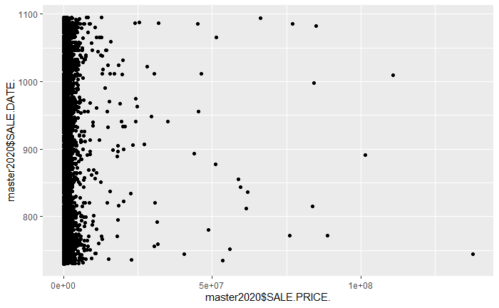

```r
attributes <- data.frame(master2020$SALE.PRICE.,
                         master2020$SALE.DATE.,
                         master2020$YEAR.BUILT.,
                         master2020$LAND.SQUARE.FEET.,
                         master2020$GROSS.SQUARE.FEET.,
                         master2020$TAX.CLASS.AT.TIME.OF.SALE.)

ggplot(attributes, aes(master2020$SALE.PRICE., master2020$SALE.DATE.)) + geom_point()
```

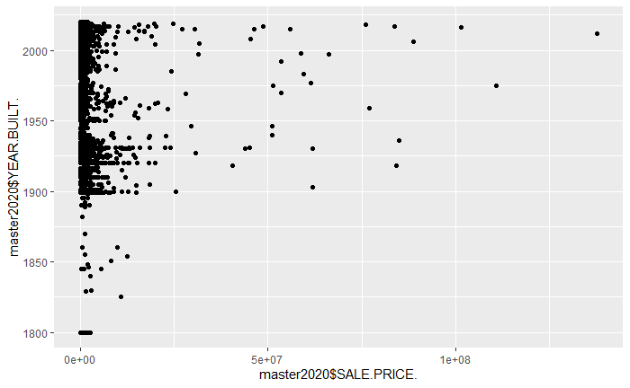

```r
ggplot(attributes, aes(master2020$SALE.PRICE., master2020$YEAR.BUILT.)) + geom_point()
```

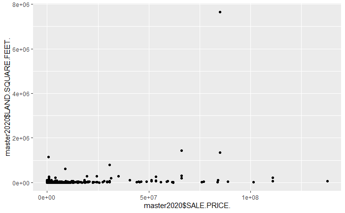

```r
ggplot(attributes, aes(master2020$SALE.PRICE., master2020$LAND.SQUARE.FEET.)) + geom_point()
```

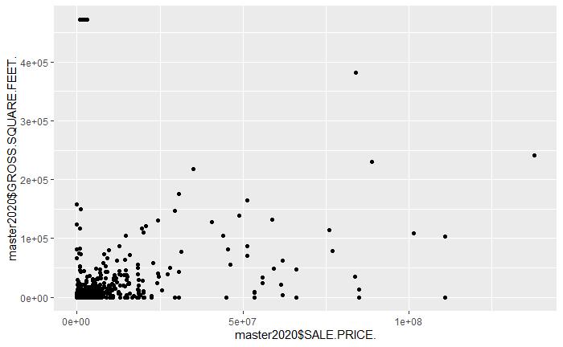

```r
ggplot(attributes, aes(master2020$SALE.PRICE., master2020$GROSS.SQUARE.FEET.)) + geom_point()
```

There seems to be some weak correlations, but no multicolinearity.

RQ3.1: Linear regression model, using all available numeric data:

```r
fit <- lm(SALE.PRICE. ~ SALE.DATE. + YEAR.BUILT. + LAND.SQUARE.FEET. + GROSS.SQUARE.FEET. + RESIDENTIAL.UNITS. + COMMERCIAL.UNITS., data=train)
summary(fit)
```

```
Call:
lm(formula = SALE.PRICE. ~ SALE.DATE. + YEAR.BUILT. + LAND.SQUARE.FEET. +
    GROSS.SQUARE.FEET. + RESIDENTIAL.UNITS. + COMMERCIAL.UNITS.,
    data = train)

Residuals:
      Min        1Q    Median        3Q       Max
-33994068   -651055   -441175    -70731 123231119

Coefficients:
                     Estimate Std. Error t value Pr(>|t|)
(Intercept)         6.701e+06  2.035e+06   3.294 0.000993 ***
SALE.DATE.          5.834e+01  3.358e+02   0.174 0.862069
YEAR.BUILT.        -2.926e+03  1.033e+03  -2.833 0.004623 **
LAND.SQUARE.FEET.   1.242e+01  4.393e-01  28.273  < 2e-16 ***
GROSS.SQUARE.FEET.  3.038e+02  5.220e+00  58.199  < 2e-16 ***
RESIDENTIAL.UNITS. -3.066e+05  5.432e+03 -56.444  < 2e-16 ***
COMMERCIAL.UNITS.  -1.365e+05  1.628e+04  -8.390  < 2e-16 ***
---
Signif. codes:  0 ‘***’ 0.001 ‘**’ 0.01 ‘*’ 0.05 ‘.’ 0.1 ‘ ’ 1

Residual standard error: 3409000 on 8539 degrees of freedom
  (5584 observations deleted due to missingness)
Multiple R-squared:  0.3445,    Adjusted R-squared:  0.344
F-statistic: 747.9 on 6 and 8539 DF,  p-value: < 2.2e-16
```

```r
predictions <- predict(fit, test, rm.na=TRUE)
error = rmse(test$SALE.PRICE., predictions)
error
```

```
[1] NA
```